# Simple Linear Regression in RStudio

Before beginning to read this tutorial, be sure to have read Chapter 3 in the Lilja text.

## The Setup

The HR manager of a local construction company is assisting the purchasing department manager with a decision. They wish to ask the CEO of they would create a new clerical position that will assist with daily processing of invoices from vendors. The purchasing manager doesn’t know, however, how much time will be needed each day for that task.

Your team estimates that there will be approximately 150 invoices per day going forward.

The HR manager passes on the request and the data to you. What do you do first, and what will your results mean?

## Tasks

1. Set up a scatter plot: Review the distribution of data and pay close attention to see if the data may be linear?
2. Generate the model: What are the regression coefficients (m and b)? Write the model you found.
3. Evaluate the regression for fit (Rsquare, ANOVA, F-statistic): Is the model a good fit for the data?
4. Check: Make sure all the assumptions for linear regression are met.
5. Hypothesize: If the equation is a good fit for the data, what is your prediction for the amount of time needed daily to process invoices assuming 150 invoices per day?

## The process

As always, I’ll begin by loading our standard helper library

```r
library(tidyverse)
```

Now let’s read the data from the given data file. Use the Files tab, navigate to the where you downloaded the file and click it to import. You can look at the data in the tab that pops up. I’ll use `head` here to display the first few rows. I’ll also `attach` the data set for convenience.

```r
attach(InvoiceHours)
head(InvoiceHours)
```

| Day | Invoices_Processed | Hours |
| --- | --- | --- |
| 1 | 30 | 1.0 |
| 2 | 57 | 2.3 |
| 3 | 241 | 3.8 |
| 4 | 58 | 1.0 |
| 5 | 83 | 1.2 |
| 6 | 25 | 0.9 |

This looks like every row is one day, and each column is one variable. That’s the format we want.

## Make a Scatterplot

A good first step is to look at a scatter plot and decide if the relationship looks at all linear. Note I added a nice title to the plot

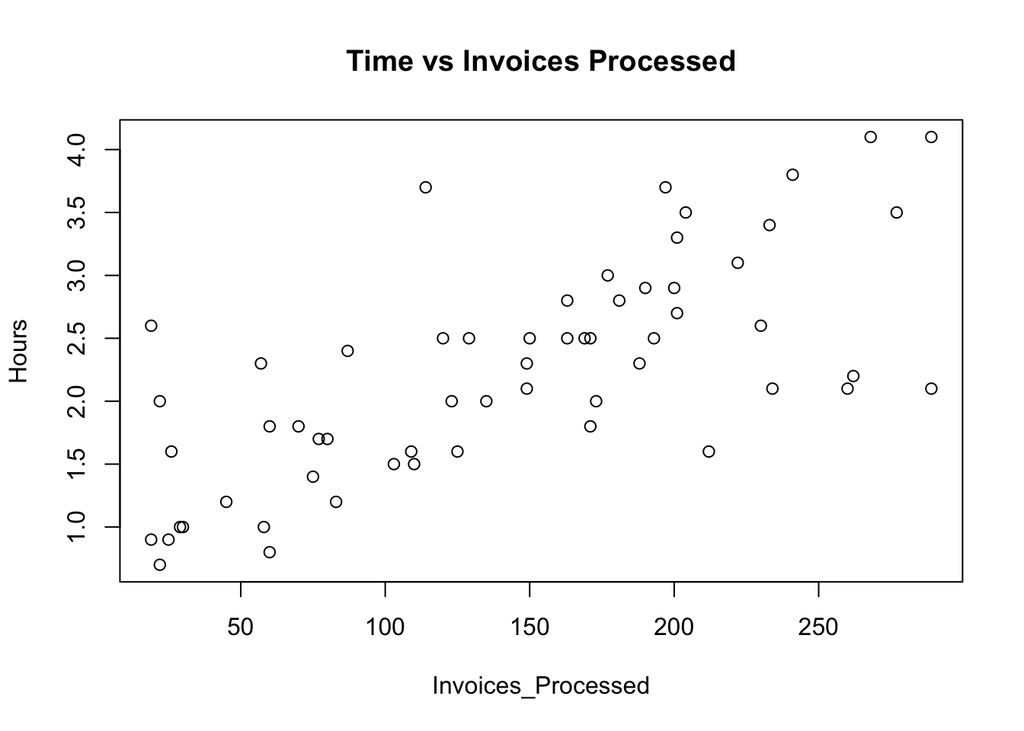

```r
plot(Hours ~ Invoices_Processed, main="Time vs Invoices Processed")
```

The plot is somewhat linear with no obvious curved pattern, so it makes sense to try and use a linear model.

## Generate the model

Let’s move on to generating the linear regression model. The first line will generate a linear model with Hours as the dependent variable (y), and Invoices_Processed as the predictor variable (x). The second line prints a summary of the model.

```r
InvoiceHours_lm <- lm(Hours ~ Invoices_Processed)
summary(InvoiceHours_lm)
```

```
##
## Call:
## lm(formula = Hours ~ Invoices_Processed)
##
## Residuals:
##      Min       1Q   Median       3Q      Max
## -1.26758 -0.41104  0.01023  0.38386  1.68034
##
## Coefficients:
##                    Estimate Std. Error t value Pr(>|t|)
## (Intercept)        1.141582   0.165712   6.889 4.87e-09 ***
## Invoices_Processed 0.007702   0.001018   7.564 3.65e-10 ***
## ---
## Signif. codes:  0 '***' 0.001 '**' 0.01 '*' 0.05 '.' 0.1 ' ' 1
##
## Residual standard error: 0.612 on 57 degrees of freedom
## Multiple R-squared:  0.501,  Adjusted R-squared:  0.4922
## F-statistic: 57.22 on 1 and 57 DF,  p-value: 3.648e-10
```

The last line, the F-statistic, shows a very small p-value, so we have very strong evidence that the coefficient on `Invoices_Processed` should not be 0. In other words, we have strong evidence there is a linear relationship!

Those last two paragraphs taken together tell me we have very strong evidence the relationship exists, but it is only a moderate relationship. We will need to tell the manager that there are likely other factors that influence the amount of time needed.

If you’d like a plot with the ‘best fit’ line you can execute these next two lines in the same code block.

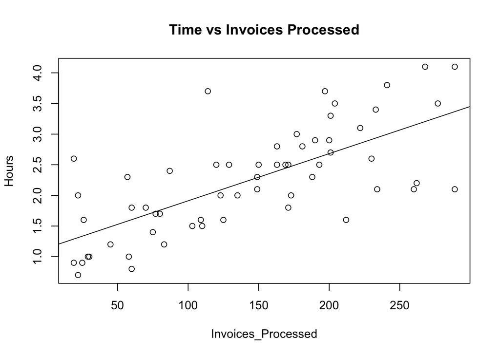

```r
plot(Hours ~ Invoices_Processed, main="Time vs Invoices Processed")
abline(InvoiceHours_lm)
```

## Residual Analysis

Before we confidently use this model however, let’s check all our requirements:

1. The relationship is linear
2. The errors are independent
3. The errors at each predictor value are normally distributed
4. The errors have equal variance across predictors (homoscedasticity)

We’ll check these by analyzing the residuals from the model.

### Residual vs Fitted Plot for #1 and #4

We will do a residual vs fitted values plot. We would like to see a scatter plot with no systematic pattern to the plot (to verify #1) and we would like to see a consistent spread (to verify #4).

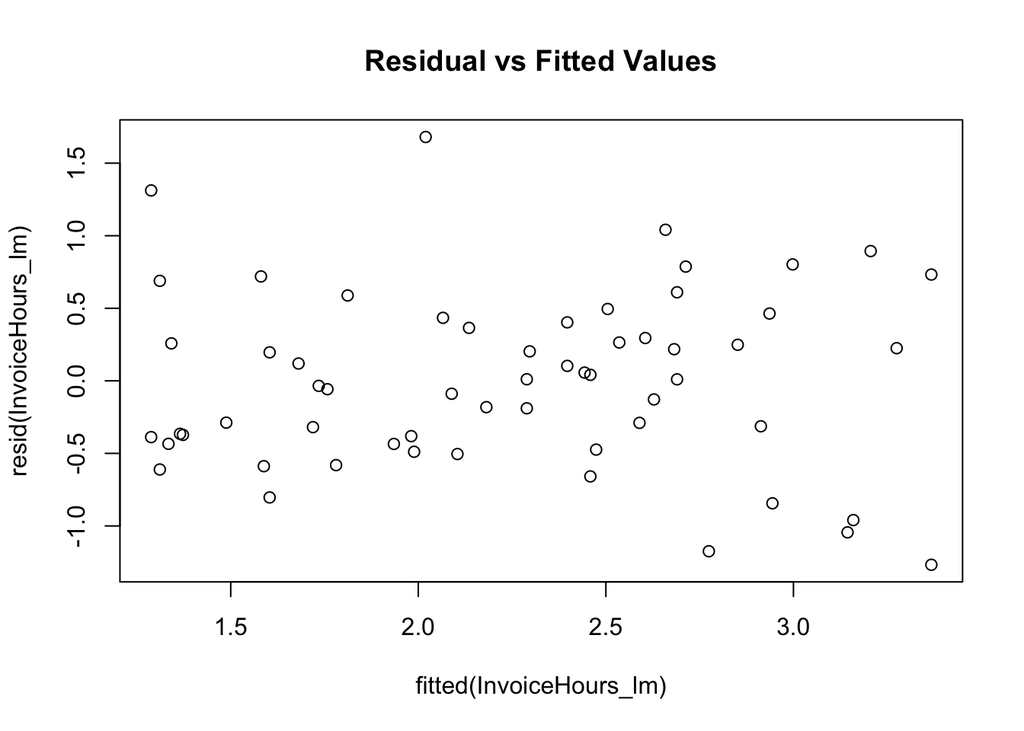

```r
plot(fitted(InvoiceHours_lm), resid(InvoiceHours_lm), main="Residual vs Fitted Values")
```

Looking across the plot we see the average is close to 0 and no excessively outlying points. A clear pattern is not evident. So #1 is satisfied. The vertical spread of the data is consistent across the plot, so that supports #4. This is good!

If we had seen a clear pattern to the data that would indicate something other than this linear relationship is affecting Hours and we should try to identify that other variable.

### Residual vs Order plot for #2

**This plot is only useful when we know the order the data was collected.** We can only do this if the data was collected in a specific order. If not then we don’t check #2.

To plot the residuals vs. order, we will use the `Day` column.

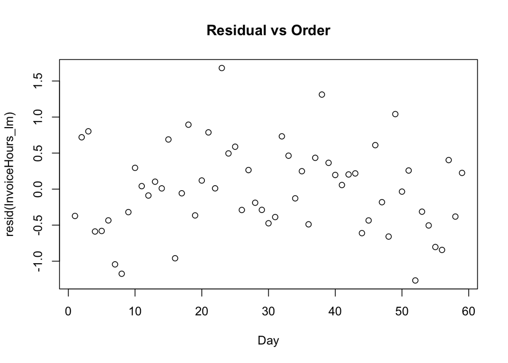

```r
plot(Day, resid(InvoiceHours_lm), main="Residual vs Order")
```

Since there is no clear pattern to the residuals we can conclude the errors are independent and #2 is satisfied.

If a residual vs. order plot shows a strong pattern we would have to conclude that time has an impact on the hours needed, so we should add that as a predictor to our model.